# Fixed Income Risk Analysis – Case Study

Noluvuyo Yumata

# **Global Macro Enviroment**

- High-Interest Rate volatility and slow easing to Disinflation
- 1Q24- Due to sticky inflation, Economic Instability & Uncertanity around geopolitical
- 2Q24- Advance economies saw inflation gradually decoding leading to market to factor first rate cuts late in 2024/2025
- Euro zone being the first to cut rates in March 2024 by 25bp Due to their CPI falling below their target sat of 2%.
- Swiss Low Inflation, low- growth mix allowed it to set the tone for Global rate cut cycle.
- US CPI has fallen from a high of 9.1 % (Jun-22) to the mid-2 % zone; core-PCE is now just below 2.5%.

# **Local Macro Enviroment**

- Highly Volatile Market(1Q24) and improving risk sentiments, boosting Investor Confidence (2Q24)
- *Inflation & MPC Policy* CPI ~ 5.2% to 5.6% (above SARB mid target) and tilted towards 4%.
- *Economic Activity* Weak to Stabilising GDP growth & improving Business sentiment. 1Q24 GDP(-0,3%) to 2Q24 (0.4) from mining, manufacturing, Transport. *Load shedding eased* Improving business and production constraints
- *Structural and Fiscal factor* Infrastructure bottleneck, high Unemployment, High Govi debt (74% of GDP) and 2024 Election results. GNU boosted Investor confidence, optimism towards accelerated reforms and embedded policy stability.
- *SARB held rates steady* at 8.25% indicating repo-rate cuts late in 2Q24 despite signs of improving Macro conditions (both Globally and locally)

# Portfolio Headline - Jun 24

**Portfolio Headline Metrics**

As at 30 June 2024

| NAV (R bn) | 4.6 |
| --- | --- |
| Total MV (R bn) | 4.0 |
| Eff. MacDur (yrs) | −0.65 |
| Spread Dur (yrs) | −0.06 |
| No. Positions | 147 |

# Asset Mix (% Holdings)

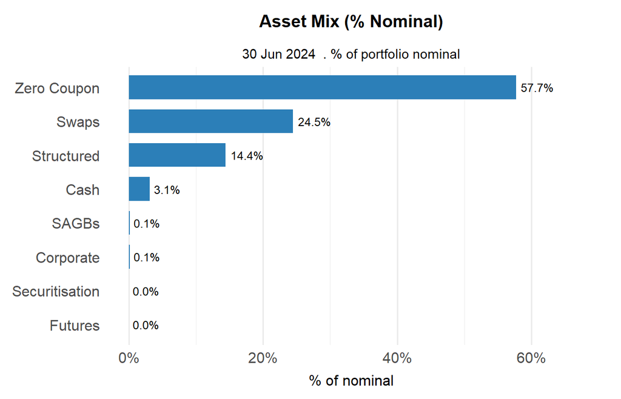

# Asset Mix (% MV)

[figure not shown]

# Issuer(%Holdings)

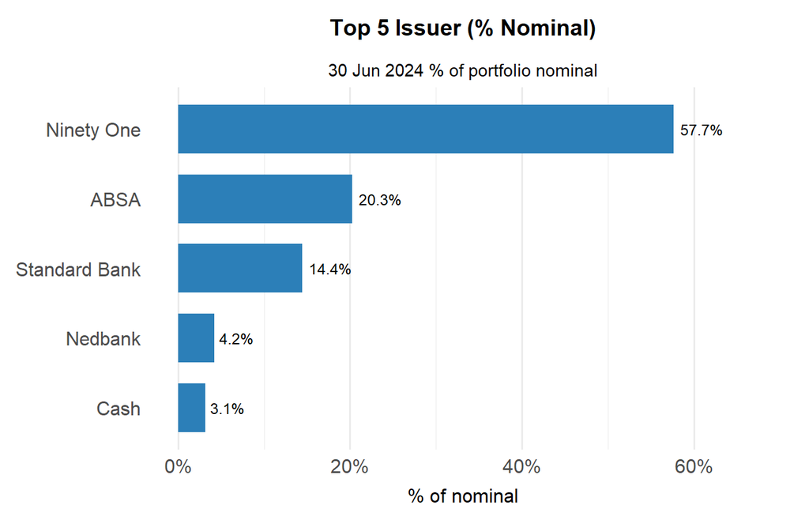

# Issuer (% mv)

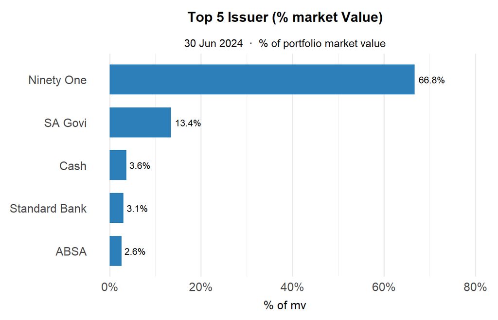

# Top instruments (% Nominal)

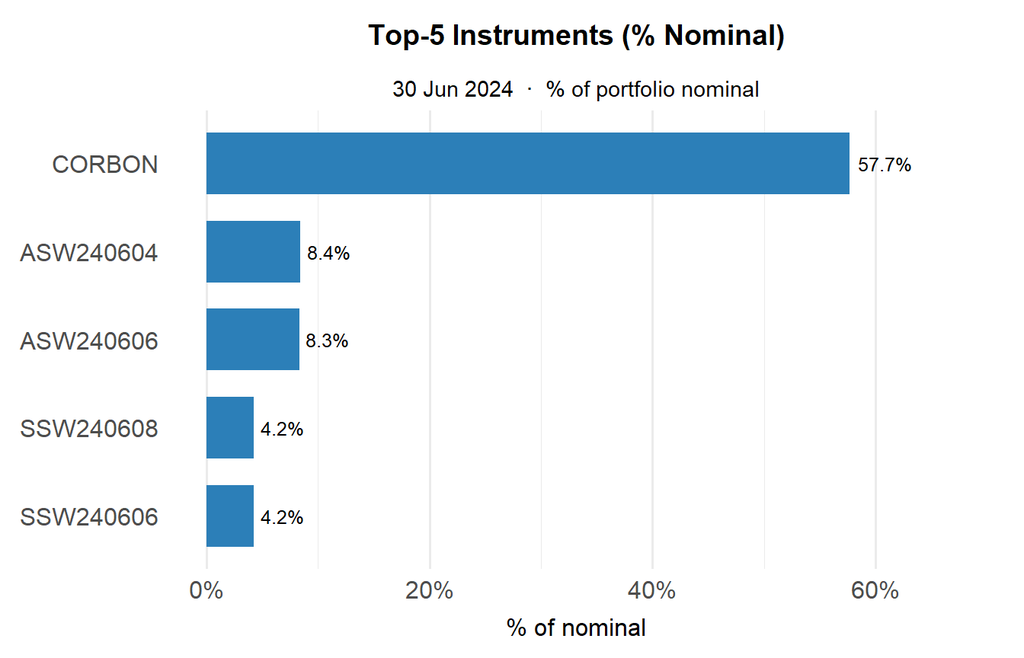

# Top instruments (% MV)

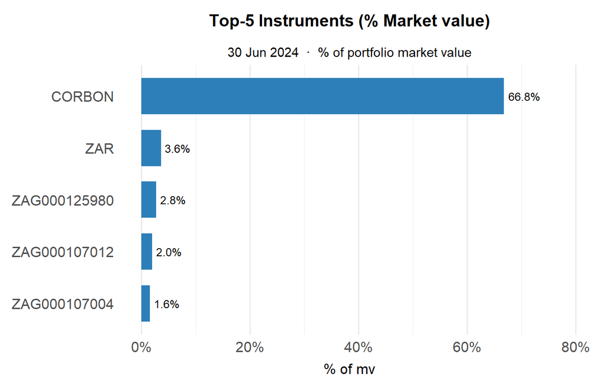

# Snapshots changes- Mar24 -> Jun24

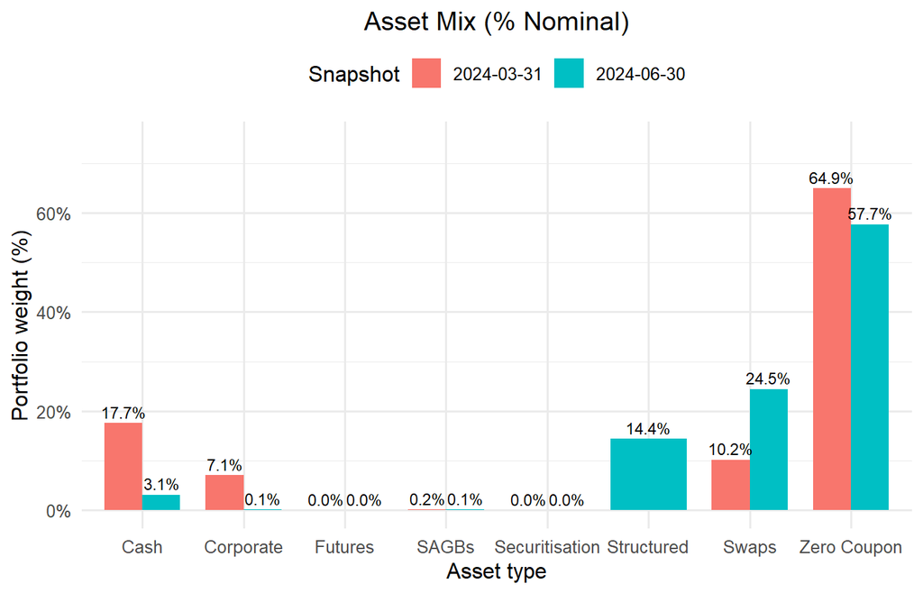

- *Cash redeployment* of R500m to Swaps(FRNs) and structured (Long Dated SAGBs) as to avoid a cash drag ahead of cutting rate cycle.
- This seemed like a strategic move to slowly increase duration and benefit from cary through FRNs without exposing the portfolio to excess risk.

# Asset Mix (% MV )

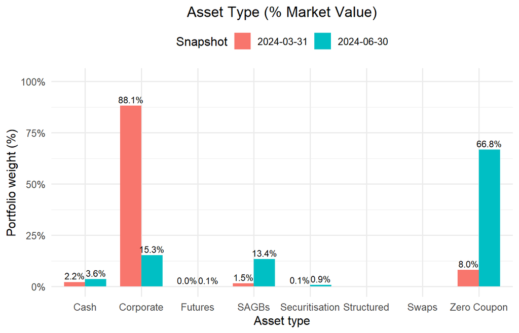

- In march the Ninety one corp bonds was highly concentrated.
- Even though it is still a leading position, however the PM increased risk through structured notes and swaps (SA bank credit and long dated bonds) ahead of decreasing intrest rate colatility in the market.

# Portfolio Changes Mar24 -> Jun 24

**Portfolio Headline Metrics**

Change from 31 Mar 2024 to 30 Jun 2024

|  | Mar 2024 | Jun 2024 | Δ (Jun–Mar) |
| --- | --- | --- | --- |
| NAV (R bn) | 3.8 | 4.6 | 0.8 |
| Total MV (R bn) | 30.7 | 4.0 | −26.7 |
| Eff. MacDur (yrs) | −0.76 | −0.65 | 0.11 |
| Spread Dur (yrs) | −0.39 | −0.06 | 0.33 |
| No. Positions | 149 | 147 | −2 |

- The portfolio Risk metrics have have uptick ahead of the easing rate cycle but were still within mandate limits.
- Duration protetion was trimmed interest rate risk conditions were improving and added FRNs to benefit from carry, increased long duration through structured notes positioning for a long only, as the US CPI has fallen from a high of 9.1 % (Jun-22) to the mid-2 % zone; core-PCE is now just below 2.5%.

# Changes Mar24 -> Jun 24

• P&L: In nominal terms the portfolio benefited positively from this strategy while managing interest risk at within low levels. Portfolio Value rose to R4,6% from R3.8%.

- SBK swaps were exited or reached maturity.

# Risk Evolution (%)

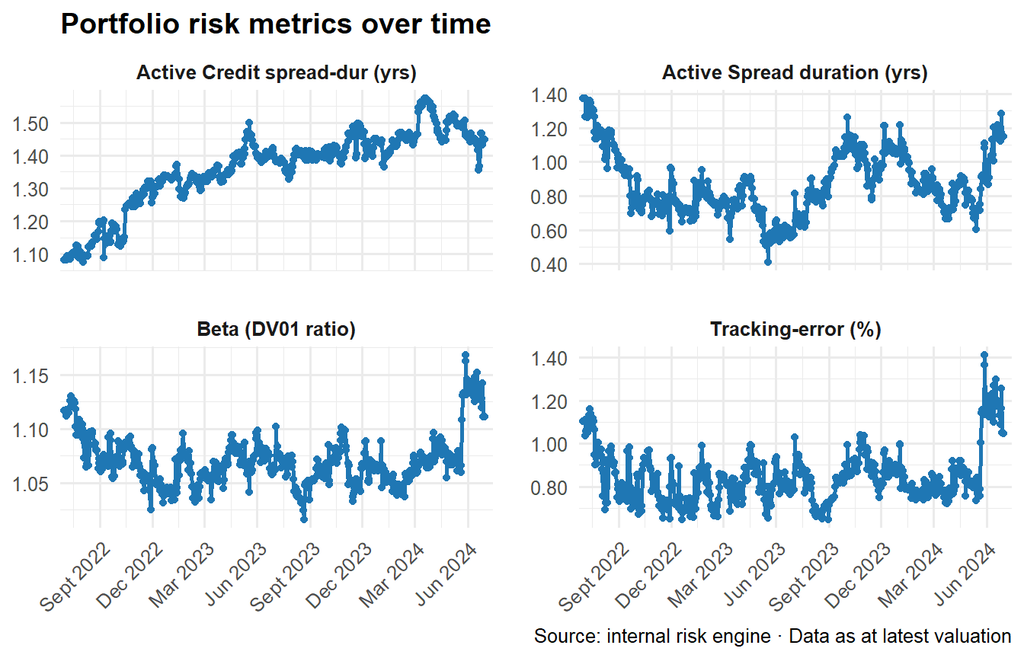

- Tracking Error > 1 % (below 1.5 reg limit): shows conviction. The managers aren’t hugging ALBI—they’re using just under 80 % of their risk budget to pursue active returns. Yet still within risk limits of 1.5%.
- Beta > 1: the portfolio has a residual long-duration bias relative to benchmark. Managers are showing that the managers have entered duration bias view taking more slight duration thatn the benchmark.
- Spread duration exposure increased with active credit spread DV01 at 1.4 yrs, the fund will gain if credit spreads tighten—but lose if SA credit stress returns.
- Between 15th to 28th of May TE Rose rose from ~0.84 to 1.14%? This seems like a deliberate re-risking with plan to benefit from the rate cut cycle especially from long dated bonds.

# Data anomalities spotted & Fixes

- Prices < 0 for the asset swaps which inflated mac durations to >1000- Seen mainly from ASW FRNs(These are real exposures)
- Put temp placeholders- approx prices at par(100) as not tonskew risk numbers while waiting for ops to investigate and update
- Cash and Ninety one zero coupon bond prices were missing - approximate cash with 1 and Ninety Corp with par 100
- Negative holdings for Repo - immaterial to the overall portfolio~ Included but put zero normalise the holdings.
- The 1 day spike in TE on 28th May worth Investigating
- Automated a report for all these data anomalities(run the report it would automatically output to the same folder this code is saved)